# Chapter 5: Exercises

Caitlyn Ralph

3/13/2018

## Conceptual Exercises

### 2. We will now derive the probability that a given observation is part of a bootstrap sample. Suppose that we obtain a bootstrap sample from a set of n observations.

#### (a) What is the probability that the first bootstrap observation is not the jth observation from the original sample? Justify your answer.

The probability that the first bootstrap observation is not the jth observation from the original sample is:

$$1 - \frac {1} {n}$$

This is because, for bootstrap, samples are taken with replacement, so the probability of selecting a certain observation is 1 minus the probability of selecting a single observation, which is 1 over the total number of observations.

#### (b) What is the probability that the second bootstrap observation is not the jth observation from the original sample?

The probability that the second bootstrap observation is not the jth observation from the original sample is again:

$$1 - \frac {1} {n}$$

This is because the probability for selecting a certain observation does not chance since everything is sampled with replacement.

#### (c) Argue that the probability that the jth observation is not in the bootstrap sample is:

$$(1 − \frac {1} {n})^n$$

Because everything is sampled with replacement, the probability that the jth observation is not in the bootstrap sample is just the probability of one selection multiplied by itself n times. We can multiply because the probability of each selection is independent.

#### (d) When n = 5, what is the probability that the jth observation is in the bootstrap sample?

$$1 - (1 − \frac {1} {n})^n = 1 - (1 - \frac {1} {5}^{5}) = 0.67232$$
#### (e) When n = 100, what is the probability that the jth observation is in the bootstrap sample?

$$1 - (1 − \frac {1} {n})^n = 1 - (1 - \frac {1} {100}^{100}) = 0.6339676587$$
#### (f) When n = 10, 000, what is the probability that the jth observa- tion is in the bootstrap sample?

$$1 - (1 − \frac {1} {n})^n = 1 - (1 - \frac {1} {10000}^{10000}) = 0.6321389536$$
#### (g) Create a plot that displays, for each integer value of n from 1 to 100,000, the probability that the jth observation is in the bootstrap sample. Comment on what you observe.

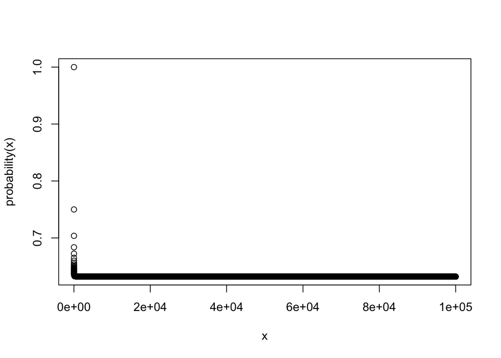

```r
probability = function(n) return(1 - (1 - 1/n)^n)
x = 1:100000
plot(x, probability(x))
```

This plot shows that the probability caps out a little over 0.60.

#### (h) We will now investigate numerically the probability that a boot- strap sample of size n = 100 contains the jth observation. Here j = 4. We repeatedly create bootstrap samples, and each time we record whether or not the fourth observation is contained in the bootstrap sample.

```r
store=rep(NA, 10000)
for(i in 1:10000){
  store[i]=sum(sample(1:100, rep=TRUE)==4)>0
}
mean(store)
```

```
## [1] 0.6421
```

The results of the bootstrap are very similar to our plot simulation from above.

### 3. We now review k-fold cross-validation.

#### (a) Explain how k-fold cross-validation is implemented.

In a k-fold cross validation, the observations are randomly divided into k groups, aka folds. The first fold is the validation set, and the method is fit on the remaining k-1 folds. The MSE is computed on observations in the held-out fold. This process is repeated k times.

#### (b) What are the advantages and disadvantages of k-fold cross-validation relative to:

##### i. The validation set approach?

The validation set approach is simple and straightforward; however, the validation estimate of the test error rate can be highly variable and only a subset of observations are used to fit the model.

##### ii. LOOCV?

LOOCV has far less bias than the validation set approach and always yields the same results because there is no randomness involved; however, there is a larger computational requirement.

k-fold CV does better with the bias-variance trade-off than LOOCV because it uses more observations than the validation set approach and less than LOOCV causing an intermadiate level of bias, and because the mean of many quantitities that are not highly correlated leads to lower variance.

## Applied Exercises

### 5. In Chapter 4, we used logistic regression to predict the probability of `default` using `income` and `balance` on the `Default` data set. We will now estimate the test error of this logistic regression model using the validation set approach. Do not forget to set a random seed before beginning your analysis.

#### (a) Fit a logistic regression model that uses `income` and `balance` to predict `default`.

```r
library(ISLR)
attach(Default)
set.seed(1)
glm.fit=glm(default~income+balance, data=Default, family=binomial)
```

#### (b) Using the validation set approach, estimate the test error of this model. In order to do this, you must perform the following steps:

##### i. Split the sample set into a training set and a validation set.

```r
train = sample(dim(Default)[1], dim(Default)[1]/2)
```

##### ii. Fit a multiple logistic regression model using only the train- ing observations.

```r
glm.train = glm(default~income+balance, data=Default, family=binomial, subset=train)
```

##### iii. Obtain a prediction of default status for each individual in the validation set by computing the posterior probability of default for that individual, and classifying the individual to the default category if the posterior probability is greater than 0.5.

```r
glm.probs=predict(glm.train,Default[-train],type="response")
glm.pred = rep("No",length(glm.probs))
glm.pred[glm.probs>0.5] = "Yes"
```

##### iv. Compute the validation set error, which is the fraction of the observations in the validation set that are misclassified.

```r
mean(glm.pred!=Default[-train,]$default)
```

```
## [1] 0.0484
```

#### (c) Repeat the process in (b) three times, using three different splits of the observations into a training set and a validation set. Com- ment on the results obtained.

```r
train = sample(dim(Default)[1], dim(Default)[1]/2)
glm.train = glm(default~income+balance, data=Default, family=binomial, subset=train)
glm.probs=predict(glm.train,Default[-train],type="response")
glm.pred = rep("No",length(glm.probs))
glm.pred[glm.probs>0.5] = "Yes"
mean(glm.pred!=Default[-train,]$default)
```

```
## [1] 0.047
```

```r
train = sample(dim(Default)[1], dim(Default)[1]/2)
glm.train = glm(default~income+balance, data=Default, family=binomial, subset=train)
glm.probs=predict(glm.train,Default[-train],type="response")
glm.pred = rep("No",length(glm.probs))
glm.pred[glm.probs>0.5] = "Yes"
mean(glm.pred!=Default[-train,]$default)
```

```
## [1] 0.0481
```

```r
train = sample(dim(Default)[1], dim(Default)[1]/2)
glm.train = glm(default~income+balance, data=Default, family=binomial, subset=train)
glm.probs=predict(glm.train,Default[-train],type="response")
glm.pred = rep("No",length(glm.probs))
glm.pred[glm.probs>0.5] = "Yes"
mean(glm.pred!=Default[-train,]$default)
```

```
## [1] 0.0464
```

#### (d) Now consider a logistic regression model that predicts the prob- ability of default using income, balance, and a dummy variable for student. Estimate the test error for this model using the validation set approach. Comment on whether or not including a dummy variable for student leads to a reduction in the test error rate.

```r
train = sample(dim(Default)[1], dim(Default)[1]/2)
glm.train = glm(default~income+balance+student, data=Default, family=binomial, subset=train)
glm.probs=predict(glm.train,Default[-train],type="response")
glm.pred = rep("No",length(glm.probs))
glm.pred[glm.probs>0.5] = "Yes"
mean(glm.pred!=Default[-train,]$default)
```

```
## [1] 0.0463
```

This does not appear to affect the test error rate.

### 7. In Sections 5.3.2 and 5.3.3, we saw that the `cv.glm()` function can be used in order to compute the LOOCV test error estimate. Alternatively, one could compute those quantities using just the `glm()` and `predict.glm()` functions, and a for loop. You will now take this ap- proach in order to compute the LOOCV error for a simple logistic regression model on the `Weekly` data set. Recall that in the context of classification problems, the LOOCV error is given in (5.4).

#### (a) Fit a logistic regression model that predicts `Direction` using `Lag1` and `Lag2`.

```r
attach(Weekly)
set.seed(1)
glm.fit = glm(Direction~Lag1+Lag2,data=Weekly,family=binomial)
```

#### (b) Fit a logistic regression model that predicts `Direction` using `Lag1` and `Lag2` using all but the first observation.

```r
glm.fit1 = glm(Direction~Lag1+Lag2,data=Weekly[-1,],family=binomial)
```

#### (c) Use the model from (b) to predict the direction of the first observation. You can do this by predicting that the first observation will go up if P(`Direction="Up"`|`Lag1`, `Lag2`) > 0.5. Was this observation correctly classified?

```r
predict.glm(glm.fit1,Weekly[1,],type="response") > 0.5
```

```
##    1
## TRUE
```

#### (d) Write a for loop from i=1 to i=n, where n is the number of observations in the data set, that performs each of the following steps:

##### i. Fit a logistic regression model using all but the ith obser- vation to predict `Direction` using `Lag1` and `Lag2`.

##### ii. Compute the posterior probability of the market moving up for the ith observation.

##### iii. Use the posterior probability for the ith observation in order to predict whether or not the market moves up.

##### iv. Determine whether or not an error was made in predicting the direction for the ith observation. If an error was made, then indicate this as a 1, and otherwise indicate it as a 0.

```r
count = rep(0,dim(Weekly)[1])
for (i in 1:dim(Weekly)[1]){
  glm.fit = glm(Direction~Lag1+Lag2,data=Weekly[-i,],family=binomial)
  up = predict.glm(glm.fit1,Weekly[i,],type="response") > 0.5
  prob = Weekly[i,]$Direction == 'Up'
  if (up!=prob)
    count[i] = 1
}
sum(count)
```

```
## [1] 483
```

#### (e) Take the average of the n numbers obtained in (d)iv in order to obtain the LOOCV estimate for the test error. Comment on the results.

```r
mean(count)
```

```
## [1] 0.4435262
```

The test error rate is 44%.

### 8. We will now perform cross-validation on a simulated data set.

#### (a) Generate a simulated data set as follows:

```r
set.seed(1)
y=rnorm(100)
x=rnorm(100)
y=x-2*x^2+rnorm(100)
```

In this data set, what is n and what is p? Write out the model used to generate the data in equation form.

n, the number of observations, is 100. p, the number of predictors, is 2.

#### (b) Create a scatterplot of X against Y. Comment on what you find.

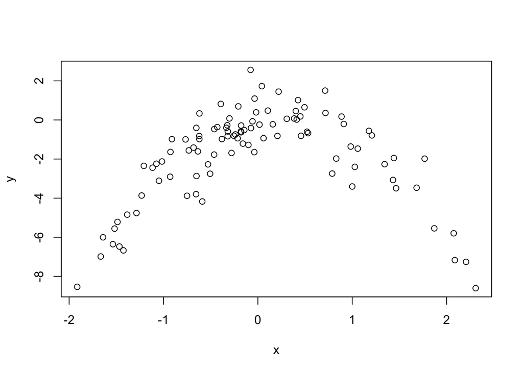

```r
plot(x,y)
```

There seems to be a bell curve happening with the relationship between X and Y. Until X reaches 0, the values of Y increase with the values of X. After 0, the values of Y decreases as the values of X increase.

#### (c) Set a random seed, and then compute the LOOCV errors that result from fitting the following four models using least squares:

```r
library(boot)
D = data.frame(x,y)
set.seed(1)
glm.fit = glm(y~x)
cv.glm(D,glm.fit)$delta
```

```
## [1] 5.890979 5.888812
```

```r
glm.fit = glm(y~poly(x,2))
cv.glm(D,glm.fit)$delta
```

```
## [1] 1.086596 1.086326
```

```r
glm.fit = glm(y~poly(x,3))
cv.glm(D,glm.fit)$delta
```

```
## [1] 1.102585 1.102227
```

```r
glm.fit = glm(y~poly(x,4))
cv.glm(D,glm.fit)$delta
```

```
## [1] 1.114772 1.114334
```

##### i.

$$Y = \beta_0 + \beta_1X + \epsilon$$

##### ii.

$$Y = \beta_0 + \beta_1X + + \beta2X^2 + \epsilon$$

##### iii.

$$Y = \beta_0 + \beta_1X + + \beta2X^2 + \beta3X^3 + \epsilon$$

##### iv.

$$Y = \beta_0 + \beta_1X + + \beta2X^2 + \beta3X^3 + \beta4X^4 + \epsilon$$

Note you may find it helpful to use the `data.frame()` function to create a single data set containing both X and Y .

#### (d) Repeat (c) using another random seed, and report your results. Are your results the same as what you got in (c)? Why?

```r
set.seed(10)
glm.fit = glm(y~x)
cv.glm(D,glm.fit)$delta
```

```
## [1] 5.890979 5.888812
```

```r
glm.fit1 = glm(y~poly(x,2))
cv.glm(D,glm.fit1)$delta
```

```
## [1] 1.086596 1.086326
```

```r
glm.fit2 = glm(y~poly(x,3))
cv.glm(D,glm.fit2)$delta
```

```
## [1] 1.102585 1.102227
```

```r
glm.fit3 = glm(y~poly(x,4))
cv.glm(D,glm.fit3)$delta
```

```
## [1] 1.114772 1.114334
```

The results are the same. The LOOCV does not change.

#### (e) Which of the models in (c) had the smallest LOOCV error? Is this what you expected? Explain your answer.

The smallest LOOCV came from model ii, the quadratic model. The original scatterplot showed a quadratic (parabolic) shape, so this makes sense.

#### (f) Comment on the statistical significance of the coefficient esti- mates that results from fitting each of the models in (c) using least squares. Do these results agree with the conclusions drawn based on the cross-validation results?

```r
summary(glm.fit)
```

```
##
## Call:
## glm(formula = y ~ x)
##
## Deviance Residuals:
##     Min       1Q   Median       3Q      Max
## -7.3469  -0.9275   0.8028   1.5608   4.3974
##
## Coefficients:
##             Estimate Std. Error t value Pr(>|t|)
## (Intercept)  -1.8185     0.2364  -7.692 1.14e-11 ***
## x             0.2430     0.2479   0.981    0.329
## ---
## Signif. codes:  0 '***' 0.001 '**' 0.01 '*' 0.05 '.' 0.1 ' ' 1
##
## (Dispersion parameter for gaussian family taken to be 5.580018)
##
##     Null deviance: 552.21  on 99  degrees of freedom
## Residual deviance: 546.84  on 98  degrees of freedom
## AIC: 459.69
##
## Number of Fisher Scoring iterations: 2
```